# nlpersonality

Capstone Project Danny Clifford October 2018

### Data Exploration

The dataset is taken from Kaggle and contains 8,600 users with 50 recent comments on the Kaggle website each and their corresponding personality type. This was user generated data from the Kaggle website and offers the most labeled personality data connected to their text data (comments) of what I could find online.

```python
import pandas as pd
import numpy as np
import seaborn as sns
import matplotlib.pyplot as plt

# import the excel document with the results
# save it as a panda's dataframe and call it data
data = pd.read_csv('raw/mbti_1.csv')

# print out a summary of the first 5 people to make sure it worked
print(data.head())
```

```
   type                                              posts
0  INFJ  'http://www.youtube.com/watch?v=qsXHcwe3krw|||...
1  ENTP  'I'm finding the lack of me in these posts ver...
2  INTP  'Good one  _____   https://www.youtube.com/wat...
3  INTJ  'Dear INTP,   I enjoyed our conversation the o...
4  ENTJ  'You're fired.|||That's another silly misconce...
```

```python
import spacy

nlp = spacy.load('en_core_web_md')
```

This is the first 5 entries of the Kaggle dataset. It comes with a 4 letter code called 'type' which is the person's peronality archetype according to their test results from the Myers Briggs Personality Index. Under 'posts' is a string of their most recent 50 posts on Kaggle.com separated by |||.

### Exploratory Visualization

The bar graph below shows the distribution of the personality types in the Kaggle database.

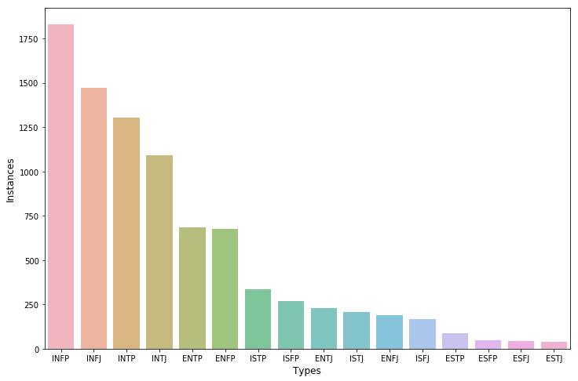

```python
d = data['type'].value_counts()
k = data['type'].value_counts().keys()

plt.figure(figsize=(12,8))
sns.barplot(d.index, d.values, alpha=0.7)
plt.ylabel('Instances', fontsize=12)
plt.xlabel('Types', fontsize=12)
plt.show()
```

Clearly Introverted and/ or iNtuitive people dominate the Kaggle forums, or at least the ones participating in the creation of the database. This will make it quite difficult to learn about those who are extroverted and sensing types (ESxx). The model would likely minimize error by simply never predicting ESxx labels.

```python
#distribution = {}
#actual_series = {}

l = float(len(data))
actual = [0.044, 0.015, 0.033, 0.021, 0.032, 0.081, 0.054, 0.088, 0.018, 0.116, 0.025, 0.138, 0.043, 0.085, 0.123, 0.087]
kaggle = []

for i in range(len(d)):
    kaggle.append(float(d[i]) / l)

keys = d.index.get_values()
values = d.get_values()
```

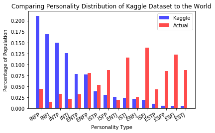

```python
from matplotlib import style

fig, ax = plt.subplots(1)
fig.autofmt_xdate()
index = np.arange(16)
bar_width = 7
opacity = 0.7

kaggle_bar = plt.bar(index*20, kaggle, bar_width,
                 alpha=opacity,
                 color='b',
                 label='Kaggle')
actual_bar = plt.bar(index*20 + bar_width, actual, bar_width,
                 alpha=opacity,
                 color='r',
                 label='Actual')

plt.xlabel('Personality Type')
plt.ylabel('Percentage of Population')
plt.title('Comparing Personality Distribution of Kaggle Dataset to the World')
plt.xticks(index*20 + bar_width, keys)
plt.legend()
plt.show()
```

The bar graph above compares the percentage of people who belong to each type on the Kaggle database and Myers-Briggs world estimates. If the data weren't already skewed enough, the people's personalities of this dataset are quite different to the general population. When it comes to creating a system for understanding personality, the data used to train the model would ideally represent the population of personalities it is trying to understand.

### Benchmark

The Benchmark I will be using to predict personality based on the data is a Logistic Regression, Random Forrest Classifier, and Support Vector Machine Classification algorithms, as I am trying to make a similar model to Yilun Wang's in his Understanding Personality through Social Media.

The average AUC across the four binary predictions he achieved with his best model was 0.661 using a large repository of Tweets of around 90,000 twitter users. Of course this dataset is much more skewed and smaller. I used another top kernel from kaggle with this same dataset where F1_score was used. His best models created an average F1_score of 0.665. See links for these projects in the conclusion.

# III. Methodology

### Data Preprocessing

First, we must do a little clean up of the data. Below shows the posts being split where '|||'s are, and saved into an array of posts. Then save the posts and type to a list (keep_list and type_list respectively) to save into a DataFrame called frame.

```python
keep_list = []
type_list = []

for i in range(len(data.type)):
    string = data['posts'][i]
    temp = np.array(string.split('|||'))
    keep_list.append(temp)
    type_list.append(df['type'][i])
    if i%2000 == 0:
        print(i)

frame = pd.DataFrame({
    'posts' : keep_list,
    'type'  : type_list
})
```

[output not shown]

Next, remove the hyperlinks and replace them with the word link. I figured this would act as a way to preserve the information that at least there was a link involved.

```python
# Go through each post to remove links
import re
pattern = re.compile('http[s]?://(?:[a-zA-Z]|[0-9]|[$-_@.&+]|[!*\\(\\),]|(?:%[0-9a-fA-F][0-9a-fA-F]))+')

for posts in frame.posts:
    for i in range(len(posts)):
        posts[i] = pattern.sub('link', posts[i])

print(frame.tail())
```

```
                                                  posts  type
8670  ['link, IxFP just because I always think of ca...  ISFP
8671  ['So...if this thread already exists someplace...  ENFP
8672  ['So many questions when i do these things.  I...  INTP
8673  ['I am very conflicted right now when it comes...  INFP
8674  ['It has been too long since I have been on pe...  INFP
```

In order to make the more difficult prediction of 1 of 16 MBTI personality types, I want to give each prediction class a number rather than the string. (I did this because I ran into some issues with keras trying to predict the string and put it through to_categorical())

```python
def type_to_numbers(type_list):

    label_list = []
    for i in type_list:
        if i == 'ENTP':
            label_list.append(0)
        if i == 'INTP':
            label_list.append(1)
        if i == 'ESTP':
            label_list.append(2)
        if i == 'ISTP':
            label_list.append(3)
        if i == 'ENFP':
            label_list.append(4)
        if i == 'INFP':
            label_list.append(5)
        if i == 'ESFP':
            label_list.append(6)
        if i == 'ISFP':
            label_list.append(7)
        if i == 'ENTJ':
            label_list.append(8)
        if i == 'INTJ':
            label_list.append(9)
        if i == 'ESTJ':
            label_list.append(10)
        if i == 'ISTJ':
            label_list.append(11)
        if i == 'ENFJ':
            label_list.append(12)
        if i == 'INFJ':
            label_list.append(13)
        if i == 'ESFJ':
            label_list.append(14)
        if i == 'ISFJ':
            label_list.append(15)

    return label_list

frame['label'] = type_to_numbers(type_list)

print(frame.head())
```

[output not shown]

*I tried making tensors of a person's language by processing each post with SpaCy and saving each of 50 to a numpy array, but I haven't gotten it to work in keras yet. It also take about 4 hours to process on my CPU

```python
#posts_vector_2d_list = []
posts_vector_1d_list = []

c=0
for posts in frame.posts:
    #p = np.empty((50,300))
    all_posts = ""
    for i in range(len(posts)):
        string = posts[i].tostring()
        s = string.decode('UTF-32')
        all_posts += s + ". "
        #post_doc = nlp(s)
        #p[i] = post_doc.vector
    all_posts_doc = nlp(all_posts)
    #posts_vector_2d_list.append(p)
    posts_vector_1d_list.append(all_posts_doc.vector)
    if c%1000==0:
        print(c)
    c+=1
```

[output not shown]

Below we can loop through each person's the MBTI type and break it into 0/1 for I/E, S/N, F/T, and J/P respectively so we can predict individual features and functions of personality.

```python
frame['e'] = 0
frame['n'] = 0
frame['t'] = 0
frame['p'] = 0


for i in range(len(type_list)):
    if frame.type[i][0] == 'E':
        frame['e'][i] = 1
    if frame.type[i][1] == 'N':
        frame['n'][i] = 1
    if frame.type[i][2] == 'T':
        frame['t'][i] = 1
    if frame.type[i][3] == 'P':
        frame['p'][i] = 1
    if i%2000 == 0:
        print(i)

print(frame.head())
```

```
0
```

[output not shown]

### Implementation

The process for which metrics, algorithms, and techniques were implemented with the given datasets or input data has been thoroughly documented. Complications that occurred during the coding process are discussed.

```python
#http://scikit-learn.org/stable/modules/generated/sklearn.model_selection.ShuffleSplit.html
#scikit-learn.org/stable/modules/generated/sklearn.model_selection.train_test_split.html
from sklearn.model_selection import ShuffleSplit
from sklearn.model_selection import train_test_split
from sklearn.linear_model import LogisticRegression
from sklearn.ensemble import RandomForestClassifier, VotingClassifier
from sklearn import metrics
from sklearn import svm
from sklearn.metrics import accuracy_score, roc_curve, f1_score
```

```python
import itertools
def plot_confusion_matrix(cm, classes,
                          normalize=True,
                          title='Confusion matrix',
                          cmap=plt.cm.Blues):

    """
    Shout out sklearn
    # http://scikit-learn.org/stable/auto_examples/model_selection/plot_confusion_matrix.html#sphx-glr-auto-examples-model-selection-plot-confusion-matrix-py

    This function prints and plots the confusion matrix.
    Normalization can be applied by setting `normalize=True`.
    """
    if normalize:
        cm = cm.astype('float') / cm.sum(axis=1)[:, np.newaxis]
    #    print("Normalized confusion matrix")
    #else:
    #    print('Confusion matrix, without normalization')

    #print(cm)

    plt.imshow(cm, interpolation='nearest', cmap=cmap)
    plt.title(title)
    plt.colorbar()
    tick_marks = np.arange(len(classes))
    plt.xticks(tick_marks, classes, rotation=45)
    plt.yticks(tick_marks, classes)

    fmt = '.2f' if normalize else 'd'
    thresh = cm.max() / 2.
    for i, j in itertools.product(range(cm.shape[0]), range(cm.shape[1])):
        plt.text(j, i, format(cm[i, j], fmt),
                 horizontalalignment="center",
                 color="white" if cm[i, j] > thresh else "black")

    plt.ylabel('True label')
    plt.xlabel('Predicted label')
    plt.tight_layout()

def show_confusion_matrix(y_test, y_pred, class_names, normalize=True):

    """
    Shout out sklearn
    # http://scikit-learn.org/stable/auto_examples/model_selection/plot_confusion_matrix.html#sphx-glr-auto-examples-model-selection-plot-confusion-matrix-py

    This function prints and plots the confusion matrix.
    Normalization can be applied by setting `normalize=True`.

    I just made it so I can use one line of code for each algorithm. #DontRepeatCode
    """


    cnf_matrix = confusion_matrix(y_test, y_pred)
    np.set_printoptions(precision=2)

    plt.figure()
    plot_confusion_matrix(cnf_matrix, classes=class_names, normalize=normalize,
                          title='Normalized confusion matrix')

    plt.show()
```

After importing all the libraries for the benchmark models, we enter into what will be a familiar cadence of steps:

Split the data into train and test sets, then create and fit the models, followed by measuring for accuracy.

### Benchmark for Extroversion vs. Introversion

```
[0.77 0.76 0.78 0.78 0.77]
LogisticRegression
Accuracy:  0.7750115260488705
AUC:  0.5155020970641103
F1 Score:  0.06513409961685825
```

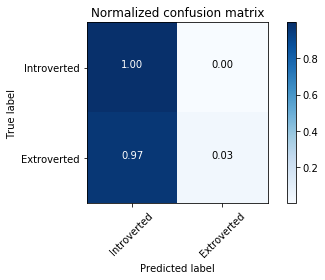

```
[0.75 0.76 0.76 0.76 0.75]
RandomForestClassifier
Accuracy:  0.7648686030428768
AUC:  0.5264218094667465
F1 Score:  0.14141414141414144
```

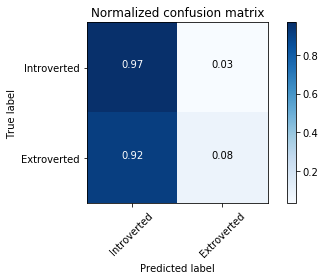

```
[0.77 0.77 0.77 0.77 0.77]
SVC
Accuracy:  0.7694790225910558
AUC:  0.5
```

```
F1 Score:  0.0
```

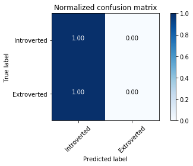

```python
X_train, X_test, y_train, y_test = train_test_split(posts_vector_1d_list, frame['e'], test_size=0.25, random_state=42, shuffle=True, stratify=frame['e'])

log_reg = LogisticRegression()
rnd_for = RandomForestClassifier()
svm_clf = svm.SVC(kernel="linear")
from sklearn.svm import SVC

from sklearn.model_selection import cross_val_score

for model in (log_reg, rnd_for, svm_clf): #svm_clf,
    scores = cross_val_score(model, X_train, y_train, cv=5)
    print(scores)
    model.fit(X_train, y_train)
    y_pred = model.predict(X_test)
    print(model.__class__.__name__)
    print("Accuracy: ", accuracy_score(y_test, y_pred))
    fpr, tpr, thresholds = metrics.roc_curve(y_test, y_pred, pos_label=1)
    auc = metrics.auc(fpr, tpr)
    print("AUC: ", auc)
    f1score = metrics.f1_score(y_test, y_pred)
    print("F1 Score: ", f1score)
    show_confusion_matrix(y_test, y_pred, ['Introverted', 'Extroverted'])
```

### Benchmark for INtuition vs. Sensing

```
[0.86 0.86 0.86 0.86 0.86]
LogisticRegression
Accuracy:  0.8635315813739051
AUC:  0.5050167224080268
F1 Score:  0.9266600594648167
```

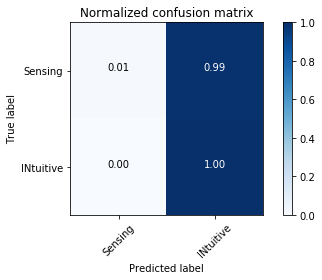

```
[0.84 0.84 0.84 0.84 0.83]
RandomForestClassifier
Accuracy:  0.8441678192715537
AUC:  0.5204791372310553
F1 Score:  0.9145601617795752
```

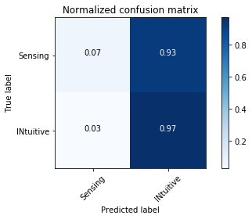

```
[0.86 0.86 0.86 0.86 0.86]
SVC
Accuracy:  0.8621484555094514
AUC:  0.5
F1 Score:  0.9259717751918792
```

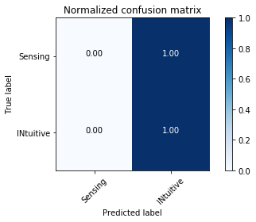

```python
X_train, X_test, y_train, y_test = train_test_split(posts_vector_1d_list, frame['n'], test_size=0.25, random_state=42, shuffle=True, stratify=frame['n'])

log_reg = LogisticRegression()
rnd_for = RandomForestClassifier()
svm_clf = svm.SVC(kernel="linear")

for model in (log_reg, rnd_for, svm_clf): #svm_clf,
    scores = cross_val_score(model, X_train, y_train, cv=5)
    print(scores)
    model.fit(X_train, y_train)
    y_pred = model.predict(X_test)
    print(model.__class__.__name__)
    print("Accuracy: ", accuracy_score(y_test, y_pred))
    fpr, tpr, thresholds = metrics.roc_curve(y_test, y_pred, pos_label=1)
    auc = metrics.auc(fpr, tpr)
    print("AUC: ", auc)
    f1score = metrics.f1_score(y_test, y_pred)
    print("F1 Score: ", f1score)
    show_confusion_matrix(y_test, y_pred, ['Sensing', 'INtuitive'])
```

###### Benchmark for Thinking vs. Feeling

```
[0.75 0.76 0.75 0.76 0.74]
LogisticRegression
Accuracy:  0.7625633932687874
AUC:  0.759441158090281
F1 Score:  0.7360328036904151
```

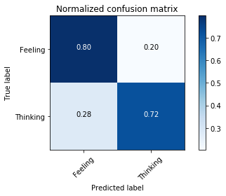

```
[0.66 0.67 0.66 0.66 0.68]
RandomForestClassifier
Accuracy:  0.681881051175657
AUC:  0.6727273505517364
F1 Score:  0.6183628318584071
```

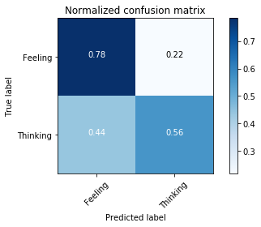

```
[0.77 0.78 0.77 0.78 0.77]
SVC
Accuracy:  0.7754725680036884
AUC:  0.7732816552952154
F1 Score:  0.7531677648251393
```

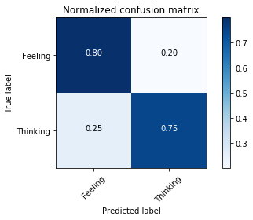

```python
X_train, X_test, y_train, y_test = train_test_split(posts_vector_1d_list, frame['t'], test_size=0.25, random_state=42, shuffle=True, stratify=frame['t'])

log_reg = LogisticRegression()
rnd_for = RandomForestClassifier()
svm_clf = svm.SVC(kernel="linear")
from sklearn.model_selection import cross_val_score

for model in (log_reg, rnd_for, svm_clf): #svm_clf,
    scores = cross_val_score(model, X_train, y_train, cv=5)
    print(scores)
    model.fit(X_train, y_train)
    y_pred = model.predict(X_test)
    print(model.__class__.__name__)
    print("Accuracy: ", accuracy_score(y_test, y_pred))
    fpr, tpr, thresholds = metrics.roc_curve(y_test, y_pred)
    auc = metrics.auc(fpr, tpr)
    print("AUC: ", auc)
    f1score = metrics.f1_score(y_test, y_pred)
    print("F1 Score: ", f1score)
    show_confusion_matrix(y_test, y_pred, ['Feeling', 'Thinking'])
```

### Benchmark for Perceiving vs. Judging

```
[0.64 0.63 0.65 0.63 0.64]
LogisticRegression
Accuracy:  0.6532964499769479
AUC:  0.583122572847888
F1 Score:  0.7623261694058154
```

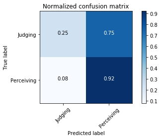

```
[0.59 0.57 0.57 0.56 0.58]
RandomForestClassifier
Accuracy:  0.5680036883356385
AUC:  0.5451759102098126
F1 Score:  0.6468149264983039
```

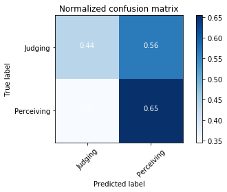

```
[0.6  0.61 0.61 0.61 0.6 ]
SVC
Accuracy:  0.6081143384047948
AUC:  0.5058398279554605
F1 Score:  0.7546189376443417
```

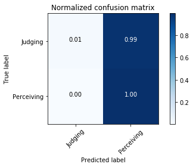

```python
X_train, X_test, y_train, y_test = train_test_split(posts_vector_1d_list, frame['p'], test_size=0.25, random_state=42, shuffle=True, stratify=frame['p'])

log_reg = LogisticRegression()
rnd_for = RandomForestClassifier()
svm_clf = svm.SVC(kernel="linear")

for model in (log_reg, rnd_for, svm_clf): #svm_clf,
    scores = cross_val_score(model, X_train, y_train, cv=5)
    print(scores)
    model.fit(X_train, y_train)
    y_pred = model.predict(X_test)
    print(model.__class__.__name__)
    print("Accuracy: ", accuracy_score(y_test, y_pred))
    fpr, tpr, thresholds = metrics.roc_curve(y_test, y_pred, pos_label=1)
    auc = metrics.auc(fpr, tpr)
    print("AUC: ", auc)
    f1score = metrics.f1_score(y_test, y_pred)
    print("F1 Score: ", f1score)
    show_confusion_matrix(y_test, y_pred, ['Judging', 'Perceiving'])
```

```
[0.77 0.76 0.78 0.78 0.77]
Accruacy:  0.7906869525126786
AUC:  0.5712150988615936
F1 Score:  0.26537216828478966
```

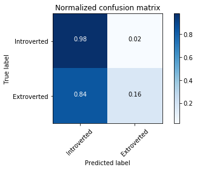

```
[0.86 0.86 0.86 0.86 0.86]
Accruacy:  0.8649147072383587
AUC:  0.5507744173984583
F1 Score:  0.9262893081761006
```

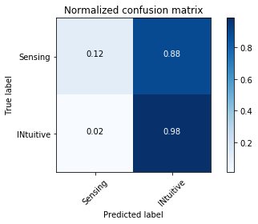

```
[0.73 0.78 0.75 0.76 0.75]
Accruacy:  0.7754725680036884
AUC:  0.7754269644645716
F1 Score:  0.7599802858551011
```

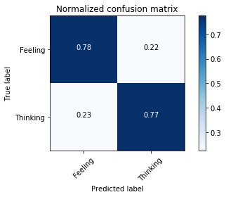

```
[0.65 0.65 0.66 0.61 0.65]
Accruacy:  0.6952512678653757
AUC:  0.6661500590958775
F1 Score:  0.7616300036062025
```

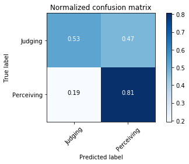

```python
from sklearn.neural_network import MLPClassifier, MLPRegressor
class_names = []
i=0
for label in [frame['e'], frame['n'], frame['t'], frame['p']]:
    if i == 0:
        class_names = ['Introverted', 'Extroverted']
    if i == 1:
        class_names = ['Sensing', 'INtuitive']
    if i == 2:
        class_names = ['Feeling', 'Thinking']
    if i == 3:
        class_names = ['Judging', 'Perceiving']
    i+=1
    X_train, X_test, y_train, y_test = train_test_split(posts_vector_1d_list, label, test_size=0.25, random_state=42, shuffle=True, stratify=label)
    simple_DNN = MLPClassifier()
    scores = cross_val_score(simple_DNN, X_train, y_train, cv=5)
    print(scores)
    simple_DNN.fit(X_train, y_train)
    y_pred = simple_DNN.predict(X_test)
    print("Accruacy: ", accuracy_score(y_test, y_pred))
    fpr, tpr, thresholds = metrics.roc_curve(y_test, y_pred, pos_label=1)
    print("AUC: ", metrics.auc(fpr, tpr))
    print("F1 Score: ", metrics.f1_score(y_test, y_pred))
    show_confusion_matrix(y_test, y_pred, class_names)
```

```python
import keras
from keras.utils import np_utils
from keras.layers import Conv2D, MaxPooling2D, GlobalAveragePooling2D, Dropout, Flatten, Dense
from keras.models import Sequential
```

```python
from sklearn.model_selection import StratifiedKFold
kfold = StratifiedKFold(n_splits=10, shuffle=True, random_state=42)
cvscores = []
cvauc = []
cvf1 = []

X_train, X_test, y_train, y_test = train_test_split(np.array(posts_vector_1d_list), frame['e'], test_size=0.25, random_state=1, shuffle=True)
X_train, X_val, y_train, y_val = train_test_split(X_train, y_train, test_size=0.3, random_state=1)
array = np.array(X_train)
test_array = np.array(X_test)
val_array = np.array(X_val)
for train, test in kfold.split(X_train, y_train):
  # create model
    model2 = Sequential()

    model2.add(Dense(300, activation='relu', input_shape=(300,)))
    #model2.add(Dense(128, activation='relu'))
    #model.add(Dense(256, activation='relu'))
    #model2.add(Dropout(0.2))
    model2.add(Dense(64, activation='relu'))
    model2.add(Dropout(0.2))
    model2.add(Dense(32, activation='relu'))
    model2.add(Dropout(0.2))
    model2.add(Dense(16, activation='relu'))
    model2.add(Dropout(0.2))
    model2.add(Dense(8, activation='relu'))
    model2.add(Dense(1, activation='sigmoid'))

    # Compile model
    model2.compile(loss='binary_crossentropy', optimizer='adam', metrics=['accuracy'])
    # Fit the model
    checkpointer = ModelCheckpoint(filepath='Extrovert_Introvert_DNN.weights.best.hdf5', verbose=0, save_best_only=True)
    model2.fit(array, y_train, epochs=50, batch_size=64, validation_data=(val_array, y_val), callbacks=[checkpointer], verbose=0, shuffle=True)
    # evaluate the model
    scores = model2.evaluate(test_array, y_test, verbose=0)
    print("%s: %.2f%%" % (model2.metrics_names[1], scores[1]*100))
    cvscores.append(scores[1] * 100)
    y_pred = model2.predict(test_array)
    fpr, tpr, thresholds = metrics.roc_curve(y_test, y_pred, pos_label=1)
    auc = metrics.auc(fpr, tpr)
    cvauc.append(auc)
    print("AUC: ", auc)
    f1 = metrics.f1_score(y_test, (y_pred>0.3).astype(int), pos_label=1)
    print("F1 Score: ", f1)
    cvf1.append(f1)
print("Average Accuracy: %.2f%% (+/- %.2f%%)" % (np.mean(cvscores), np.std(cvscores)))
print("Average AUC: %.4f (+/- %.4f)" % (np.mean(cvauc), np.std(cvauc)))
print("Average F1_Score: %.4f (+/- %.4f)" % (np.mean(cvf1), np.std(cvf1)))
```

```
acc: 80.27%
AUC:  0.7968733514681395
F1 Score:  0.5546942291128337
acc: 79.62%
AUC:  0.7890085643380413
F1 Score:  0.5524769101595298
acc: 79.62%
AUC:  0.791965600444043
F1 Score:  0.5602094240837696
acc: 80.22%
AUC:  0.7924294829745364
F1 Score:  0.5539568345323741
acc: 75.47%
AUC:  0.7953297522442969
F1 Score:  0.5367057371992597
acc: 78.61%
AUC:  0.7897310513447432
F1 Score:  0.5308775731310943
acc: 80.04%
AUC:  0.795437551892916
F1 Score:  0.5561139028475712
acc: 80.27%
AUC:  0.7961990302618842
F1 Score:  0.5546058879392213
acc: 79.21%
AUC:  0.7946152928710027
F1 Score:  0.5492033739456419
acc: 78.75%
AUC:  0.7928400390831066
F1 Score:  0.5304812834224598
Average Accuracy: 79.21% (+/- 1.37%)
Average AUC: 0.7934 (+/- 0.0026)
Average F1_Score: 0.5479 (+/- 0.0104)
```

```python
model = Sequential()

model.add(Dense(300, activation='relu', input_shape=(300,)))
model.add(Dense(64, activation='relu'))
#model.add(Dense(256, activation='relu'))
model.add(Dropout(0.2))
#model.add(Dense(64, activation='relu'))
#model.add(Dropout(0.2))
model.add(Dense(32, activation='relu'))
model.add(Dropout(0.2))
model.add(Dense(16, activation='relu'))
model.add(Dropout(0.2))
model.add(Dense(8, activation='relu'))
model.add(Dense(1, activation='sigmoid'))
model.summary()
```

```
_________________________________________________________________
Layer (type)                 Output Shape              Param #
=================================================================
dense_1469 (Dense)           (None, 300)               90300
_________________________________________________________________
dense_1470 (Dense)           (None, 64)                19264
_________________________________________________________________
dropout_683 (Dropout)        (None, 64)                0
_________________________________________________________________
dense_1471 (Dense)           (None, 32)                2080
_________________________________________________________________
dropout_684 (Dropout)        (None, 32)                0
_________________________________________________________________
dense_1472 (Dense)           (None, 16)                528
_________________________________________________________________
dropout_685 (Dropout)        (None, 16)                0
_________________________________________________________________
dense_1473 (Dense)           (None, 8)                 136
_________________________________________________________________
dense_1474 (Dense)           (None, 1)                 9
=================================================================
Total params: 112,317
Trainable params: 112,317
Non-trainable params: 0
_________________________________________________________________
```

```python
model.compile(loss='binary_crossentropy', optimizer='adam', metrics=['accuracy'])
```

```python
X_train, X_test, y_train, y_test = train_test_split(np.array(posts_vector_1d_list), frame['e'], test_size=0.25, random_state=1, shuffle=True)
X_train, X_val, y_train, y_val = train_test_split(X_train, y_train, test_size=0.3, random_state=1)

# train the model
checkpointer = ModelCheckpoint(filepath='Extrovert_Introvert_DNN.weights.best.hdf5', verbose=1, save_best_only=True)
#scores = cross_val_score(model, X_train, y_train, cv=5)
#print(scores)
# fit the model
#hist = model.fit(X_train, y_train, batch_size = 80, epochs =20, validation_data=(X_val, y_val), callbacks=[checkpointer], verbose=2, shuffle=True)
hist = model.fit(X_train, y_train, batch_size = 64, epochs =50, validation_data=(X_val, y_val), callbacks=[checkpointer], verbose=2, shuffle=True)
```

```
Train on 4554 samples, validate on 1952 samples
 - 4s - loss: 0.5652 - acc: 0.7705 - val_loss: 0.5414 - val_acc: 0.7720

Epoch 00001: val_loss improved from inf to 0.54138, saving model to Extrovert_Introvert_DNN.weights.best.hdf5
 - 2s - loss: 0.5373 - acc: 0.7758 - val_loss: 0.5366 - val_acc: 0.7720

Epoch 00002: val_loss improved from 0.54138 to 0.53665, saving model to Extrovert_Introvert_DNN.weights.best.hdf5
 - 3s - loss: 0.5356 - acc: 0.7758 - val_loss: 0.5323 - val_acc: 0.7720

Epoch 00003: val_loss improved from 0.53665 to 0.53229, saving model to Extrovert_Introvert_DNN.weights.best.hdf5
 - 3s - loss: 0.5284 - acc: 0.7758 - val_loss: 0.5237 - val_acc: 0.7720

Epoch 00004: val_loss improved from 0.53229 to 0.52366, saving model to Extrovert_Introvert_DNN.weights.best.hdf5
 - 2s - loss: 0.5200 - acc: 0.7758 - val_loss: 0.5161 - val_acc: 0.7720

Epoch 00005: val_loss improved from 0.52366 to 0.51612, saving model to Extrovert_Introvert_DNN.weights.best.hdf5
 - 3s - loss: 0.5060 - acc: 0.7758 - val_loss: 0.5140 - val_acc: 0.7720

Epoch 00006: val_loss improved from 0.51612 to 0.51403, saving model to Extrovert_Introvert_DNN.weights.best.hdf5
 - 2s - loss: 0.4999 - acc: 0.7758 - val_loss: 0.4932 - val_acc: 0.7720

Epoch 00007: val_loss improved from 0.51403 to 0.49316, saving model to Extrovert_Introvert_DNN.weights.best.hdf5
 - 2s - loss: 0.4883 - acc: 0.7758 - val_loss: 0.4850 - val_acc: 0.7720

Epoch 00008: val_loss improved from 0.49316 to 0.48499, saving model to Extrovert_Introvert_DNN.weights.best.hdf5
 - 2s - loss: 0.4830 - acc: 0.7758 - val_loss: 0.4838 - val_acc: 0.7720

Epoch 00009: val_loss improved from 0.48499 to 0.48378, saving model to Extrovert_Introvert_DNN.weights.best.hdf5
 - 3s - loss: 0.4811 - acc: 0.7773 - val_loss: 0.4791 - val_acc: 0.7720

Epoch 00010: val_loss improved from 0.48378 to 0.47913, saving model to Extrovert_Introvert_DNN.weights.best.hdf5
 - 2s - loss: 0.4766 - acc: 0.7800 - val_loss: 0.4927 - val_acc: 0.7720

Epoch 00011: val_loss did not improve
 - 2s - loss: 0.4698 - acc: 0.7791 - val_loss: 0.4872 - val_acc: 0.7818

Epoch 00012: val_loss did not improve
 - 2s - loss: 0.4637 - acc: 0.7819 - val_loss: 0.4974 - val_acc: 0.7756

Epoch 00013: val_loss did not improve
```

[output cut: 96 more lines]

```
 - 2s - loss: 0.4147 - acc: 0.8158 - val_loss: 0.4490 - val_acc: 0.7971

Epoch 00046: val_loss did not improve
 - 2s - loss: 0.4146 - acc: 0.8160 - val_loss: 0.4356 - val_acc: 0.8064

Epoch 00047: val_loss did not improve
 - 3s - loss: 0.4063 - acc: 0.8197 - val_loss: 0.4393 - val_acc: 0.8105

Epoch 00048: val_loss did not improve
 - 3s - loss: 0.4117 - acc: 0.8147 - val_loss: 0.4462 - val_acc: 0.7992

Epoch 00049: val_loss did not improve
 - 2s - loss: 0.4087 - acc: 0.8197 - val_loss: 0.4526 - val_acc: 0.8033

Epoch 00050: val_loss did not improve
```

```
Test accuracy:  0.8017519593733475
AUC:  0.794797634829837
F1 Score:  0.5546806649168854
```

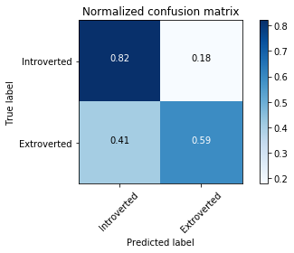

```python
from sklearn import metrics
# load the model weights that had the best validation score
model.load_weights('Extrovert_Introvert_DNN.weights.best.hdf5')

# evaluate the model's accuracy

score = model.evaluate(X_test, y_test, verbose = 0)

# print the accuracy
print('\nTest accuracy: ', score[1])

y_pred = model.predict(X_test)
fpr, tpr, thresholds = metrics.roc_curve(y_test, y_pred, pos_label=1)
auc = metrics.auc(fpr, tpr)
print("AUC: ", auc)
#https://stackoverflow.com/questions/38015181/accuracy-score-valueerror-cant-handle-mix-of-binary-and-continuous
print("F1 Score: ", metrics.f1_score(y_test, (y_pred>0.3).astype(int), pos_label=1))
show_confusion_matrix(y_test, (y_pred>0.3).astype(int), ['Introverted', 'Extroverted'])
```

```python
from sklearn.model_selection import StratifiedKFold
kfold = StratifiedKFold(n_splits=10, shuffle=True, random_state=42)
cvscores = []
cvauc = []
cvf1 = []

X_train, X_test, y_train, y_test = train_test_split(np.array(posts_vector_1d_list), frame['n'], test_size=0.25, random_state=1, shuffle=True)
X_train, X_val, y_train, y_val = train_test_split(X_train, y_train, test_size=0.3, random_state=1)
array = np.array(X_train)
test_array = np.array(X_test)
val_array = np.array(X_val)
for train, test in kfold.split(X_train, y_train):
  # create model
    model2 = Sequential()

    model2.add(Dense(300, activation='relu', input_shape=(300,)))
    model2.add(Dense(128, activation='relu'))
    #model.add(Dense(256, activation='relu'))
    model2.add(Dropout(0.2))
    #model2.add(Dense(64, activation='relu'))
    #model2.add(Dropout(0.2))
    model2.add(Dense(16, activation='relu'))
    model2.add(Dropout(0.2))
    model2.add(Dense(8, activation='relu'))
    model2.add(Dense(1, activation='sigmoid'))

    # Compile model
    model2.compile(loss='binary_crossentropy', optimizer='adam', metrics=['accuracy'])
    # Fit the model
    checkpointer = ModelCheckpoint(filepath='Intuitive_Sensing_DNN.weights.best.hdf5', verbose=0, save_best_only=True)
    model2.fit(array, y_train, epochs=25, batch_size=75, validation_data=(val_array, y_val), callbacks=[checkpointer], verbose=0, shuffle=True)
    # evaluate the model
    scores = model2.evaluate(test_array, y_test, verbose=0)
    print("%s: %.2f%%" % (model2.metrics_names[1], scores[1]*100))
    cvscores.append(scores[1] * 100)
    y_pred = model2.predict(test_array)
    fpr, tpr, thresholds = metrics.roc_curve(y_test, y_pred, pos_label=1)
    auc = metrics.auc(fpr, tpr)
    cvauc.append(auc)
    print("AUC: ", auc)
    f1 = metrics.f1_score(y_test, (y_pred>0.346).astype(int), pos_label=1)
    print("F1 Score: ", f1)
    cvf1.append(f1)
print("Average Accuracy: %.2f%% (+/- %.2f%%)" % (np.mean(cvscores), np.std(cvscores)))
print("Average AUC: %.4f (+/- %.4f)" % (np.mean(cvauc), np.std(cvauc)))
print("Average F1_Score: %.4f (+/- %.2f)" % (np.mean(cvf1), np.std(cvf1)))
```

```
acc: 86.81%
AUC:  0.7556731334509112
F1 Score:  0.9312638580931264
acc: 87.14%
AUC:  0.752646450854336
F1 Score:  0.9312638580931264
acc: 87.32%
AUC:  0.755874153723616
F1 Score:  0.9312638580931264
acc: 87.14%
AUC:  0.7580256395668583
F1 Score:  0.9312638580931264
acc: 87.18%
AUC:  0.7599476588723901
F1 Score:  0.9312638580931264
acc: 87.83%
AUC:  0.7572983633915533
F1 Score:  0.9312638580931264
acc: 87.55%
AUC:  0.7575695511179381
F1 Score:  0.9328043639970246
acc: 87.23%
AUC:  0.7590392748098841
F1 Score:  0.932472691161867
acc: 84.88%
AUC:  0.7581365800003793
F1 Score:  0.9312638580931264
acc: 87.37%
AUC:  0.7607138116098688
F1 Score:  0.9312638580931264
Average Accuracy: 87.04% (+/- 0.77%)
Average AUC: 0.7575 (+/- 0.0022)
Average F1_Score: 0.9315 (+/- 0.00)
```

```python
X_train, X_test, y_train, y_test = train_test_split(np.array(posts_vector_1d_list), frame['n'], test_size=0.25, random_state=1, shuffle=True)
X_train, X_val, y_train, y_val = train_test_split(X_train, y_train, test_size=0.3, random_state=1)
# train the model
checkpointer = ModelCheckpoint(filepath='Intuitive_Sensing_DNN.weights.best.hdf5', verbose=1, save_best_only=True)

# fit the model
hist = model.fit(X_train, y_train, batch_size = 32, epochs =50, validation_data=(X_val, y_val), callbacks=[checkpointer], verbose=2, shuffle=True)
```

```
Train on 4554 samples, validate on 1952 samples
 - 5s - loss: 0.4573 - acc: 0.8430 - val_loss: 0.3963 - val_acc: 0.8653

Epoch 00001: val_loss improved from inf to 0.39625, saving model to Intuitive_Sensing_DNN.weights.best.hdf5
 - 5s - loss: 0.4288 - acc: 0.8562 - val_loss: 0.3934 - val_acc: 0.8653

Epoch 00002: val_loss improved from 0.39625 to 0.39343, saving model to Intuitive_Sensing_DNN.weights.best.hdf5
 - 5s - loss: 0.4208 - acc: 0.8562 - val_loss: 0.3938 - val_acc: 0.8658

Epoch 00003: val_loss did not improve
 - 5s - loss: 0.4198 - acc: 0.8562 - val_loss: 0.3901 - val_acc: 0.8653

Epoch 00004: val_loss improved from 0.39343 to 0.39014, saving model to Intuitive_Sensing_DNN.weights.best.hdf5
 - 5s - loss: 0.4147 - acc: 0.8562 - val_loss: 0.3875 - val_acc: 0.8653

Epoch 00005: val_loss improved from 0.39014 to 0.38754, saving model to Intuitive_Sensing_DNN.weights.best.hdf5
 - 5s - loss: 0.4062 - acc: 0.8562 - val_loss: 0.3857 - val_acc: 0.8653

Epoch 00006: val_loss improved from 0.38754 to 0.38570, saving model to Intuitive_Sensing_DNN.weights.best.hdf5
 - 5s - loss: 0.4055 - acc: 0.8562 - val_loss: 0.3850 - val_acc: 0.8653

Epoch 00007: val_loss improved from 0.38570 to 0.38498, saving model to Intuitive_Sensing_DNN.weights.best.hdf5
 - 5s - loss: 0.4009 - acc: 0.8564 - val_loss: 0.3802 - val_acc: 0.8653

Epoch 00008: val_loss improved from 0.38498 to 0.38016, saving model to Intuitive_Sensing_DNN.weights.best.hdf5
 - 5s - loss: 0.3923 - acc: 0.8560 - val_loss: 0.3844 - val_acc: 0.8653

Epoch 00009: val_loss did not improve
 - 5s - loss: 0.3847 - acc: 0.8568 - val_loss: 0.3655 - val_acc: 0.8653

Epoch 00010: val_loss improved from 0.38016 to 0.36554, saving model to Intuitive_Sensing_DNN.weights.best.hdf5
 - 5s - loss: 0.3811 - acc: 0.8568 - val_loss: 0.3687 - val_acc: 0.8653

Epoch 00011: val_loss did not improve
 - 5s - loss: 0.3785 - acc: 0.8564 - val_loss: 0.3713 - val_acc: 0.8653

Epoch 00012: val_loss did not improve
 - 5s - loss: 0.3748 - acc: 0.8568 - val_loss: 0.3757 - val_acc: 0.8653

Epoch 00013: val_loss did not improve
```

[output cut: 96 more lines]

```
 - 5s - loss: 0.3396 - acc: 0.8632 - val_loss: 0.3503 - val_acc: 0.8612

Epoch 00046: val_loss did not improve
 - 5s - loss: 0.3390 - acc: 0.8676 - val_loss: 0.3598 - val_acc: 0.8683

Epoch 00047: val_loss did not improve
 - 5s - loss: 0.3381 - acc: 0.8696 - val_loss: 0.3448 - val_acc: 0.8658

Epoch 00048: val_loss improved from 0.34624 to 0.34482, saving model to Intuitive_Sensing_DNN.weights.best.hdf5
 - 5s - loss: 0.3382 - acc: 0.8707 - val_loss: 0.3461 - val_acc: 0.8642

Epoch 00049: val_loss did not improve
 - 5s - loss: 0.3378 - acc: 0.8682 - val_loss: 0.3449 - val_acc: 0.8648

Epoch 00050: val_loss did not improve
```

```
Test accuracy:  0.8759797138517054
AUC:  0.7602662570404506
F1 Score:  0.9312638580931264
```

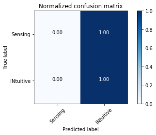

```python
# load the model weights that had the best validation score
model.load_weights('Intuitive_Sensing_DNN.weights.best.hdf5')

# evaluate the model's accuracy
score = model.evaluate(X_test, y_test, verbose = 0)

# print the accuracy
print('\nTest accuracy: ', score[1])

y_pred = model.predict(X_test)
fpr, tpr, thresholds = metrics.roc_curve(y_test, y_pred, pos_label=1)
auc = metrics.auc(fpr, tpr)
print("AUC: ", auc)
print("F1 Score: ", metrics.f1_score(y_test, (y_pred>0.346).astype(int), pos_label=1))
show_confusion_matrix(y_test, (y_pred>0.346).astype(int), ['Sensing', 'INtuitive'])
```

```python
from sklearn.model_selection import StratifiedKFold
kfold = StratifiedKFold(n_splits=10, shuffle=True, random_state=42)
cvscores = []
cvauc = []
cvf1 = []

X_train, X_test, y_train, y_test = train_test_split(np.array(posts_vector_1d_list), frame['t'], test_size=0.25, random_state=1, shuffle=True)
X_train, X_val, y_train, y_val = train_test_split(X_train, y_train, test_size=0.3, random_state=1)
array = np.array(X_train)
test_array = np.array(X_test)
val_array = np.array(X_val)
for train, test in kfold.split(X_train, y_train):
  # create model
    model2 = Sequential()

    model2.add(Dense(300, activation='relu', input_shape=(300,)))
    model2.add(Dense(128, activation='relu'))
    #model.add(Dense(256, activation='relu'))
    model2.add(Dropout(0.2))
    model2.add(Dense(64, activation='relu'))
    model2.add(Dropout(0.2))
    model2.add(Dense(16, activation='relu'))
    model2.add(Dropout(0.2))
    model2.add(Dense(8, activation='relu'))
    model2.add(Dense(1, activation='sigmoid'))

    # Compile model
    model2.compile(loss='binary_crossentropy', optimizer='adam', metrics=['accuracy'])
    # Fit the model
    checkpointer = ModelCheckpoint(filepath='Thinking_Feeling_DNN.weights.best.hdf5', verbose=0, save_best_only=True)
    model2.fit(array, y_train, epochs=64, batch_size=64, validation_data=(val_array, y_val), callbacks=[checkpointer], verbose=0, shuffle=True)
    # evaluate the model
    scores = model2.evaluate(test_array, y_test, verbose=0)
    print("%s: %.2f%%" % (model2.metrics_names[1], scores[1]*100))
    cvscores.append(scores[1] * 100)
    y_pred = model2.predict(test_array)
    fpr, tpr, thresholds = metrics.roc_curve(y_test, y_pred, pos_label=1)
    auc = metrics.auc(fpr, tpr)
    cvauc.append(auc)
    print("AUC: ", auc)
    f1 = metrics.f1_score(y_test, (y_pred>0.445).astype(int), pos_label=1)
    print("F1 Score: ", f1)
    cvf1.append(f1)
print("Average Accuracy: %.2f%% (+/- %.2f%%)" % (np.mean(cvscores), np.std(cvscores)))
print("Average AUC: %.4f (+/- %.4f)" % (np.mean(cvauc), np.std(cvauc)))
print("Average F1_Score: %.4f (+/- %.4f)" % (np.mean(cvf1), np.std(cvf1)))
```

```
acc: 77.69%
AUC:  0.8789416721293565
F1 Score:  0.73355629877369
acc: 78.47%
AUC:  0.8832896318147055
F1 Score:  0.753972602739726
acc: 79.76%
AUC:  0.8804729323719
F1 Score:  0.7837837837837838
acc: 78.75%
AUC:  0.8790423904730689
F1 Score:  0.7638668779714738
acc: 80.73%
AUC:  0.886002198732656
F1 Score:  0.7959866220735785
acc: 78.28%
AUC:  0.8823208579154376
F1 Score:  0.7482093663911845
acc: 80.36%
AUC:  0.8848567409592483
F1 Score:  0.7984862819299906
acc: 80.22%
AUC:  0.8834287596962745
F1 Score:  0.796688132474701
acc: 80.22%
AUC:  0.8816346075057359
F1 Score:  0.7945330296127562
acc: 78.75%
AUC:  0.8770314377799628
F1 Score:  0.7798573975044564
Average Accuracy: 79.32% (+/- 1.00%)
Average AUC: 0.8817 (+/- 0.0027)
Average F1_Score: 0.7749 (+/- 0.0222)
```

```python
model2 = Sequential()

model2.add(Dense(300, activation='relu', input_shape=(300,)))
model2.add(Dense(128, activation='relu'))
#model.add(Dense(256, activation='relu'))
model2.add(Dropout(0.2))
model2.add(Dense(64, activation='relu'))
model2.add(Dropout(0.2))
model2.add(Dense(16, activation='relu'))
model2.add(Dropout(0.2))
model2.add(Dense(8, activation='relu'))
model2.add(Dense(1, activation='sigmoid'))
model2.summary()
model2.compile(loss='binary_crossentropy', optimizer='adam', metrics=['accuracy'])

X_train, X_test, y_train, y_test = train_test_split(np.array(posts_vector_1d_list), frame['t'], test_size=0.25, random_state=1, shuffle=True)
X_train, X_val, y_train, y_val = train_test_split(X_train, y_train, test_size=0.3, random_state=1)
# train the model
checkpointer = ModelCheckpoint(filepath='Thinking_Feeling_DNN.weights.best.hdf5', verbose=1, save_best_only=True)

# fit the model
hist = model2.fit(X_train, y_train, batch_size = 64, epochs =64, validation_data=(X_val, y_val), callbacks=[checkpointer], verbose=2, shuffle=True)
```

```
_________________________________________________________________
Layer (type)                 Output Shape              Param #
=================================================================
dense_1475 (Dense)           (None, 300)               90300
_________________________________________________________________
dense_1476 (Dense)           (None, 128)               38528
_________________________________________________________________
dropout_686 (Dropout)        (None, 128)               0
_________________________________________________________________
dense_1477 (Dense)           (None, 64)                8256
_________________________________________________________________
dropout_687 (Dropout)        (None, 64)                0
_________________________________________________________________
dense_1478 (Dense)           (None, 16)                1040
_________________________________________________________________
dropout_688 (Dropout)        (None, 16)                0
_________________________________________________________________
dense_1479 (Dense)           (None, 8)                 136
_________________________________________________________________
dense_1480 (Dense)           (None, 1)                 9
=================================================================
Total params: 138,269
Trainable params: 138,269
Non-trainable params: 0
_________________________________________________________________
Train on 4554 samples, validate on 1952 samples
 - 22s - loss: 0.6906 - acc: 0.5299 - val_loss: 0.6865 - val_acc: 0.5435

Epoch 00001: val_loss improved from inf to 0.68653, saving model to Thinking_Feeling_DNN.weights.best.hdf5
 - 3s - loss: 0.6785 - acc: 0.5507 - val_loss: 0.6428 - val_acc: 0.6650

Epoch 00002: val_loss improved from 0.68653 to 0.64283, saving model to Thinking_Feeling_DNN.weights.best.hdf5
 - 3s - loss: 0.6159 - acc: 0.6711 - val_loss: 0.6060 - val_acc: 0.6619

Epoch 00003: val_loss improved from 0.64283 to 0.60602, saving model to Thinking_Feeling_DNN.weights.best.hdf5
 - 3s - loss: 0.6073 - acc: 0.6785 - val_loss: 0.6240 - val_acc: 0.6419

Epoch 00004: val_loss did not improve
 - 3s - loss: 0.5781 - acc: 0.7165 - val_loss: 0.5488 - val_acc: 0.7290

```

[output cut: 163 more lines]

```
 - 3s - loss: 0.4112 - acc: 0.8081 - val_loss: 0.4567 - val_acc: 0.8023

Epoch 00060: val_loss did not improve
 - 3s - loss: 0.3831 - acc: 0.8287 - val_loss: 0.4750 - val_acc: 0.7884

Epoch 00061: val_loss did not improve
 - 3s - loss: 0.3810 - acc: 0.8230 - val_loss: 0.4648 - val_acc: 0.7920

Epoch 00062: val_loss did not improve
 - 3s - loss: 0.3963 - acc: 0.8175 - val_loss: 0.4656 - val_acc: 0.8023

Epoch 00063: val_loss did not improve
 - 3s - loss: 0.3900 - acc: 0.8213 - val_loss: 0.4737 - val_acc: 0.7992

Epoch 00064: val_loss did not improve
```

```
Test accuracy:  0.7989857078368019
AUC:  0.8813879329181689
F1 Score:  0.7945075757575757
```

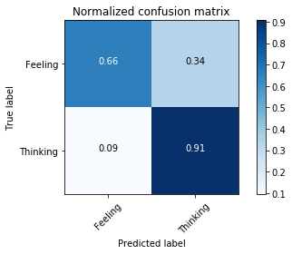

```python
# load the model weights that had the best validation score
model2.load_weights('Thinking_Feeling_DNN.weights.best.hdf5')

# evaluate the model's accuracy
score = model2.evaluate(X_test, y_test, verbose = 0)

# print the accuracy
print('\nTest accuracy: ', score[1])

y_pred = model2.predict(X_test)
fpr, tpr, thresholds = metrics.roc_curve(y_test, y_pred, pos_label=1)
auc = metrics.auc(fpr, tpr)
print("AUC: ", auc)
print("F1 Score: ", metrics.f1_score(y_test, (y_pred>0.445).astype(int), pos_label=1))
show_confusion_matrix(y_test, (y_pred>0.3).astype(int), ['Feeling', 'Thinking'])
```

```python
from sklearn.model_selection import StratifiedKFold
kfold = StratifiedKFold(n_splits=10, shuffle=True, random_state=42)
cvscores = []
cvauc = []
cvf1 = []

X_train, X_test, y_train, y_test = train_test_split(np.array(posts_vector_1d_list), frame['p'], test_size=0.25, random_state=1, shuffle=True)
X_train, X_val, y_train, y_val = train_test_split(X_train, y_train, test_size=0.3, random_state=1)
array = np.array(X_train)
test_array = np.array(X_test)
val_array = np.array(X_val)
for train, test in kfold.split(X_train, y_train):
  # create model
    model2 = Sequential()

    model2.add(Dense(300, activation='relu', input_shape=(300,)))
    model2.add(Dense(128, activation='relu'))
    #model.add(Dense(256, activation='relu'))
    model2.add(Dropout(0.2))
    model2.add(Dense(64, activation='relu'))
    model2.add(Dropout(0.2))
    model2.add(Dense(16, activation='relu'))
    model2.add(Dropout(0.2))
    model2.add(Dense(8, activation='relu'))
    model2.add(Dense(1, activation='sigmoid'))

    # Compile model
    model2.compile(loss='binary_crossentropy', optimizer='adam', metrics=['accuracy'])
    # Fit the model
    checkpointer = ModelCheckpoint(filepath='Perceiving_Judging_DNN.weights.best.hdf5', verbose=0, save_best_only=True)
    model2.fit(array, y_train, epochs=30, batch_size=32, validation_data=(val_array, y_val), callbacks=[checkpointer], verbose=0, shuffle=True)
    # evaluate the model
    scores = model2.evaluate(test_array, y_test, verbose=0)
    print("%s: %.2f%%" % (model2.metrics_names[1], scores[1]*100))
    cvscores.append(scores[1] * 100)
    y_pred = model2.predict(test_array)
    fpr, tpr, thresholds = metrics.roc_curve(y_test, y_pred, pos_label=1)
    auc = metrics.auc(fpr, tpr)
    cvauc.append(auc)
    print("AUC: ", auc)
    f1 = metrics.f1_score(y_test, (y_pred>0.43).astype(int), pos_label=1)
    print("F1 Score: ", f1)
    cvf1.append(f1)
print("Average Accuracy: %.2f%% (+/- %.2f%%)" % (np.mean(cvscores), np.std(cvscores)))
print("Average AUC: %.4f (+/- %.4f)" % (np.mean(cvauc), np.std(cvauc)))
print("Average F1_Score: %.4f (+/- %.4f)" % (np.mean(cvf1), np.std(cvf1)))
```

```
acc: 68.05%
AUC:  0.7257711777162579
F1 Score:  0.7652955409609402
acc: 67.91%
AUC:  0.7209900447886719
F1 Score:  0.7556675062972292
acc: 68.33%
AUC:  0.7191204422325703
F1 Score:  0.7697325505544683
acc: 68.93%
AUC:  0.7324912565187165
F1 Score:  0.7679298465393047
acc: 67.63%
AUC:  0.723384167320094
F1 Score:  0.7554925584691707
acc: 66.48%
AUC:  0.7050686409954146
F1 Score:  0.7534482758620689
acc: 68.37%
AUC:  0.7221430997174705
F1 Score:  0.7661396574440053
acc: 68.14%
AUC:  0.7243940905268136
F1 Score:  0.7659309916070873
acc: 67.73%
AUC:  0.7207909050014314
F1 Score:  0.7666995722277065
acc: 62.52%
AUC:  0.6975893417541015
F1 Score:  0.7550665894614939
Average Accuracy: 67.41% (+/- 1.74%)
Average AUC: 0.7192 (+/- 0.0097)
Average F1_Score: 0.7621 (+/- 0.0060)
```

```python
X_train, X_test, y_train, y_test = train_test_split(np.array(posts_vector_1d_list), frame['p'], test_size=0.25, random_state=1, shuffle=True)
X_train, X_val, y_train, y_val = train_test_split(X_train, y_train, test_size=0.3, random_state=1)
# train the model
checkpointer = ModelCheckpoint(filepath='Perceiving_Judging_DNN.weights.best.hdf5', verbose=1, save_best_only=True)

# fit the model
#hist = model.fit(X_train, y_train, batch_size = 64, epochs =30, validation_data=(X_val, y_val), callbacks=[checkpointer], verbose=2, shuffle=True)
hist = model2.fit(X_train, y_train, batch_size = 64, epochs =30, validation_data=(X_val, y_val), callbacks=[checkpointer], verbose=2, shuffle=True)
```

```
Train on 4554 samples, validate on 1952 samples
 - 3s - loss: 0.5900 - acc: 0.6755 - val_loss: 0.6294 - val_acc: 0.6562

Epoch 00001: val_loss improved from inf to 0.62939, saving model to Perceiving_Judging_DNN.weights.best.hdf5
 - 3s - loss: 0.5888 - acc: 0.6842 - val_loss: 0.6118 - val_acc: 0.6829

Epoch 00002: val_loss improved from 0.62939 to 0.61176, saving model to Perceiving_Judging_DNN.weights.best.hdf5
 - 3s - loss: 0.5848 - acc: 0.6825 - val_loss: 0.6313 - val_acc: 0.6373

Epoch 00003: val_loss did not improve
 - 3s - loss: 0.5950 - acc: 0.6790 - val_loss: 0.6466 - val_acc: 0.6255

Epoch 00004: val_loss did not improve
 - 3s - loss: 0.5890 - acc: 0.6803 - val_loss: 0.6172 - val_acc: 0.6685

Epoch 00005: val_loss did not improve
 - 3s - loss: 0.5867 - acc: 0.6845 - val_loss: 0.6188 - val_acc: 0.6624

Epoch 00006: val_loss did not improve
 - 3s - loss: 0.5805 - acc: 0.6957 - val_loss: 0.6282 - val_acc: 0.6711

Epoch 00007: val_loss did not improve
 - 3s - loss: 0.5871 - acc: 0.6840 - val_loss: 0.6187 - val_acc: 0.6696

Epoch 00008: val_loss did not improve
 - 3s - loss: 0.5797 - acc: 0.6972 - val_loss: 0.6159 - val_acc: 0.6814

Epoch 00009: val_loss did not improve
 - 3s - loss: 0.5885 - acc: 0.6803 - val_loss: 0.6222 - val_acc: 0.6742

Epoch 00010: val_loss did not improve
 - 3s - loss: 0.5783 - acc: 0.6915 - val_loss: 0.6429 - val_acc: 0.6404

Epoch 00011: val_loss did not improve
 - 3s - loss: 0.5870 - acc: 0.6893 - val_loss: 0.6042 - val_acc: 0.6829

Epoch 00012: val_loss improved from 0.61176 to 0.60424, saving model to Perceiving_Judging_DNN.weights.best.hdf5
 - 3s - loss: 0.5829 - acc: 0.6910 - val_loss: 0.6066 - val_acc: 0.6890

Epoch 00013: val_loss did not improve
```

[output cut: 36 more lines]

```
 - 3s - loss: 0.5589 - acc: 0.7126 - val_loss: 0.6221 - val_acc: 0.6762

Epoch 00026: val_loss did not improve
 - 3s - loss: 0.5660 - acc: 0.7036 - val_loss: 0.6082 - val_acc: 0.6860

Epoch 00027: val_loss did not improve
 - 3s - loss: 0.5651 - acc: 0.7110 - val_loss: 0.6262 - val_acc: 0.6578

Epoch 00028: val_loss did not improve
 - 3s - loss: 0.5673 - acc: 0.7064 - val_loss: 0.6155 - val_acc: 0.6778

Epoch 00029: val_loss did not improve
 - 3s - loss: 0.5610 - acc: 0.7200 - val_loss: 0.6056 - val_acc: 0.6906

Epoch 00030: val_loss did not improve
```

```
Test accuracy:  0.6846473032343272
AUC:  0.7300562392095573
F1 Score:  0.7657967032967032
```

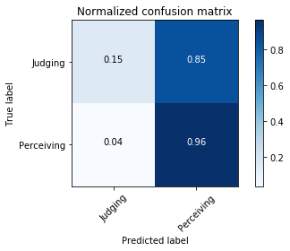

```python
# load the model weights that had the best validation score
model2.load_weights('Perceiving_Judging_DNN.weights.best.hdf5')

# evaluate the model's accuracy
score = model2.evaluate(X_test, y_test, verbose = 0)

# print the accuracy
print('\nTest accuracy: ', score[1])

y_pred = model2.predict(X_test)
fpr, tpr, thresholds = metrics.roc_curve(y_test, y_pred)
auc = metrics.auc(fpr, tpr)
print("AUC: ", auc)
print("F1 Score: ", metrics.f1_score(y_test, (y_pred>0.43).astype(int), pos_label=1))
show_confusion_matrix(y_test, (y_pred>0.3).astype(int), ['Judging', 'Perceiving'])
```

```python
def guess_personality(string):
    weights = ['Extrovert_Introvert_DNN.weights.best.hdf5', 'Intuitive_Sensing_DNN.weights.best.hdf5']
    weights2 = ['Thinking_Feeling_DNN.weights.best.hdf5', 'Perceiving_Judging_DNN.weights.best.hdf5']

    guess = ""

    for w in weights:
        model.load_weights(w)
        doc = nlp(string)
        tester = doc.vector.reshape(1, -1)
        prediction = model.predict(tester)
        if w == weights[0]:
            print("Introverted = 0, Extroverted = 1: ", prediction[0][0])
            if prediction[0][0] < 0.346:
                guess += "I"
            else:
                guess += "E"
        if w == weights[1]:
            print("Sensing = 0, INtuitive = 1: ", prediction[0][0])
            if prediction[0][0] < 0.5:
                guess += "S"
            else:
                guess += "N"
    for w in weights2:
        model2.load_weights(w)
        doc = nlp(string)
        tester = doc.vector.reshape(1, -1)
        prediction = model.predict(tester)
        if w == weights2[0]:
            print("Feeling = 0, Thinking = 1: ", prediction[0][0])
            if prediction[0][0] < 0.445:
                guess += "F"
            else:
                guess += "T"
        if w == weights2[1]:
            print("Judging = 0, Perceiving = 1: ", prediction[0][0])
            if prediction[0][0] < 0.43:
                guess += "J"
            else:
                guess += "P"
    return guess
```

```python
string = "Enter anything you'd like here and I'll guess your personality. I'm and ENTP, so let's see how it works"

guess = guess_personality(string)
print(guess)
```

```
Introverted = 0, Extroverted = 1:  0.6243913
Sensing = 0, INtuitive = 1:  0.57463396
Feeling = 0, Thinking = 1:  0.57463396
Judging = 0, Perceiving = 1:  0.57463396
ENTP
```